# Enron Email Analysis

Nihal Sachindra

18-05-2025

## Introduction:

This project explores internal email patterns within Enron using R and RStudio. The study focuses on examining sender behavior, exploring the roles of employees within the organization, analyzing communication trends over time, and investigating the content of email subjects.Through this analysis, I aim to exhibit meaningful insights into organizational dynamics and information flow within Enron.

## Libraries Used:

## Step 1: Load the Data in RStudio

```r
load("Enron (1).Rdata")
ls()
```

```
## [1] "employeelist"  "message"       "recipientinfo" "referenceinfo"
```

## Step 2: Explore the Data

```r
str(employeelist)
```

```
## 'data.frame':    149 obs. of  9 variables:
##  $ eid      : num  13 6 19 115 129 18 33 149 52 21 ...
##  $ firstName: chr  "Marie" "Mark" "Lindy" "Lisa" ...
##  $ lastName : chr  "Heard" "Taylor" "Donoho" "Gang" ...
##  $ Email_id : chr  "marie.heard@enron.com" "mark.e.taylor@enron.com" "lindy.donoho@enron.com" "lisa.gang@enron.com" ...
##  $ Email2   : chr  "" "mark.taylor@enron.com" "ldonoho@enron.com" "" ...
##  $ Email3   : chr  "" "e.taylor@enron.com" "" "" ...
##  $ EMail4   : chr  "" "" "" "" ...
##  $ folder   : chr  "heard-m" "taylor-m" "donoho-l" "gang-l" ...
##  $ status   : Factor w/ 10 levels "CEO","Director",..: NA 3 3 7 1 2 7 3 3 2 ...
```

```r
head(employeelist)
```

```
##   eid firstName lastName                Email_id                     Email2
## 1  13     Marie    Heard   marie.heard@enron.com
## 2   6      Mark   Taylor mark.e.taylor@enron.com      mark.taylor@enron.com
## 3  19     Lindy   Donoho  lindy.donoho@enron.com          ldonoho@enron.com
## 4 115      Lisa     Gang     lisa.gang@enron.com
## 5 129   Jeffrey Skilling jeff.skilling@enron.com jeffrey.skilling@enron.com
## 6  18      Lynn    Blair    lynn.blair@enron.com        lynnblair@enron.com
##               Email3 EMail4     folder   status
## 1                              heard-m     <NA>
## 2 e.taylor@enron.com          taylor-m Employee
## 3                             donoho-l Employee
## 4                               gang-l      N/A
## 5                           skilling-j      CEO
## 6                              blair-l Director
```

```r
summary(employeelist)
```

```
##       eid          firstName           lastName           Email_id
##  Min.   :  1.00   Length:149         Length:149         Length:149
##  1st Qu.: 38.00   Class :character   Class :character   Class :character
##  Median : 75.00   Mode  :character   Mode  :character   Mode  :character
##  Mean   : 75.07
##  3rd Qu.:112.00
##  Max.   :150.00
##
##     Email2             Email3             EMail4             folder
##  Length:149         Length:149         Length:149         Length:149
##  Class :character   Class :character   Class :character   Class :character
##  Mode  :character   Mode  :character   Mode  :character   Mode  :character
##
##
##
##
##             status
##  Employee      :41
##  N/A           :31
##  Vice President:23
##  Director      :14
##  Manager       :14
##  (Other)       :25
##  NA's          : 1
```

```r
str(message)
```

```
## 'data.frame':    252759 obs. of  5 variables:
##  $ mid       : int  52 53 54 55 56 57 58 59 60 61 ...
##  $ sender    : Factor w/ 17527 levels "-persson@ricemail.ricefinancial.com",..: 13252 12358 12358 13252 12358 5565 5088 2900 2868 2361 ...
##  $ date      : Date, format: "2000-01-21" "2000-01-24" ...
##  $ message_id: Factor w/ 252759 levels "<10000282.1075847198841.JavaMail.evans@thyme>",..: 20268 164410 44339 4329 50733 181388 129861 111357 132891 248375 ...
##  $ subject   : chr  "ENRON HOSTS ANNUAL ANALYST CONFERENCE PROVIDES BUSINESS OVERVIEW AND GOALS FOR 2000" "Over $50 -- You made it happen!" "Over $50 -- You made it happen!" "ROAD-SHOW.COM Q4i.COM CHOOSE ENRON TO DELIVER FINANCIAL WEB CONTENT" ...
```

```r
head(message)
```

```
##   mid                    sender       date
## 1  52   press.release@enron.com 2000-01-21
## 2  53 office.chairman@enron.com 2000-01-24
## 3  54 office.chairman@enron.com 2000-01-24
## 4  55   press.release@enron.com 2000-02-02
## 5  56 office.chairman@enron.com 2000-02-07
## 6  57          foothi19@idt.net 2000-08-25
##                                      message_id
## 1 <12435833.1075863606729.JavaMail.evans@thyme>
## 2 <29664079.1075863606676.JavaMail.evans@thyme>
## 3 <15300605.1075863606629.JavaMail.evans@thyme>
## 4 <10522232.1075863606538.JavaMail.evans@thyme>
## 5 <16056123.1075863606515.JavaMail.evans@thyme>
## 6 <31680362.1075863730221.JavaMail.evans@thyme>
##                                                                               subject
## 1 ENRON HOSTS ANNUAL ANALYST CONFERENCE PROVIDES BUSINESS OVERVIEW AND GOALS FOR 2000
## 2                                                     Over $50 -- You made it happen!
## 3                                                     Over $50 -- You made it happen!
## 4                 ROAD-SHOW.COM Q4i.COM CHOOSE ENRON TO DELIVER FINANCIAL WEB CONTENT
## 5                                                        Fortune Most Admired Ranking
## 6                                                   WPTF Friday Credo Veritas Burrito
```

```r
summary(message)
```

```
##       mid                               sender            date
##  Min.   :    52   jeff.dasovich@enron.com  :  6273   Min.   :0001-05-30
##  1st Qu.: 88565   j.kaminski@enron.com     :  5838   1st Qu.:2000-12-01
##  Median :186421   kay.mann@enron.com       :  5100   Median :2001-05-21
##  Mean   :190260   sara.shackleton@enron.com:  4797   Mean   :1999-04-15
##  3rd Qu.:279962   tana.jones@enron.com     :  4437   3rd Qu.:2001-10-25
##  Max.   :404927   chris.germany@enron.com  :  3686   Max.   :2044-01-04
##                   (Other)                  :222628
##                                          message_id       subject
##  <10000282.1075847198841.JavaMail.evans@thyme>:     1   Length:252759
##  <10000478.1075841161605.JavaMail.evans@thyme>:     1   Class :character
##  <1000097.1075860055721.JavaMail.evans@thyme> :     1   Mode  :character
##  <1000099.1075858574579.JavaMail.evans@thyme> :     1
##  <1000115.1075852075775.JavaMail.evans@thyme> :     1
##  <1000122.1075858816233.JavaMail.evans@thyme> :     1
##  (Other)                                      :252753
```

```r
str(recipientinfo)
```

```
## 'data.frame':    2064442 obs. of  4 variables:
##  $ rid   : int  67 68 69 70 71 72 73 74 75 76 ...
##  $ mid   : num  52 53 54 55 56 56 57 58 59 60 ...
##  $ rtype : Factor w/ 3 levels "BCC","CC","TO": 3 3 3 3 3 3 3 3 3 3 ...
##  $ rvalue: Factor w/ 68084 levels "--migrated--sgrendel@ercot.com",..: 2060 2046 2049 2060 2065 18193 10002 56479 54146 63168 ...
```

```r
head(recipientinfo)
```

```
##   rid mid rtype                            rvalue
## 1  67  52    TO           all.worldwide@enron.com
## 2  68  53    TO            all.downtown@enron.com
## 3  69  54    TO     all.enron-worldwide@enron.com
## 4  70  55    TO           all.worldwide@enron.com
## 5  71  56    TO all_enron_north.america@enron.com
## 6  72  56    TO       ec.communications@enron.com
```

```r
summary(recipientinfo)
```

```
##       rid               mid         rtype
##  Min.   :     67   Min.   :    52   BCC: 253713
##  1st Qu.: 718289   1st Qu.:105438   CC : 253735
##  Median :1515296   Median :198263   TO :1556994
##  Mean   :1543862   Mean   :196168
##  3rd Qu.:2309682   3rd Qu.:280673
##  Max.   :3242063   Max.   :404927
##
##                        rvalue
##  no.address@enron.com     :  19198
##  jeff.dasovich@enron.com  :  11137
##  richard.shapiro@enron.com:  11015
##  steven.j.kean@enron.com  :  10873
##  james.d.steffes@enron.com:  10615
##  tana.jones@enron.com     :   9781
##  (Other)                  :1991823
```

```r
glimpse(employeelist)
```

```
## Rows: 149
## Columns: 9
## $ eid       <dbl> 13, 6, 19, 115, 129, 18, 33, 149, 52, 21, 127, 2, 22, 107, 9…
## $ firstName <chr> "Marie", "Mark", "Lindy", "Lisa", "Jeffrey", "Lynn", "Kim", …
## $ lastName  <chr> "Heard", "Taylor", "Donoho", "Gang", "Skilling", "Blair", "W…
## $ Email_id  <chr> "marie.heard@enron.com", "mark.e.taylor@enron.com", "lindy.d…
## $ Email2    <chr> "", "mark.taylor@enron.com", "ldonoho@enron.com", "", "jeffr…
## $ Email3    <chr> "", "e.taylor@enron.com", "", "", "", "", "", "", "", "", ""…
## $ EMail4    <chr> "", "", "", "", "", "", "", "", "", "", "", "", "", "", "", …
## $ folder    <chr> "heard-m", "taylor-m", "donoho-l", "gang-l", "skilling-j", "…
## $ status    <fct> NA, Employee, Employee, N/A, CEO, Director, N/A, Employee, E…
```

```r
glimpse(message)
```

```
## Rows: 252,759
## Columns: 5
## $ mid        <int> 52, 53, 54, 55, 56, 57, 58, 59, 60, 61, 62, 63, 64, 65, 66,…
## $ sender     <fct> press.release@enron.com, office.chairman@enron.com, office.…
## $ date       <date> 2000-01-21, 2000-01-24, 2000-01-24, 2000-02-02, 2000-02-07…
## $ message_id <fct> <12435833.1075863606729.JavaMail.evans@thyme>, <29664079.10…
## $ subject    <chr> "ENRON HOSTS ANNUAL ANALYST CONFERENCE PROVIDES BUSINESS OV…
```

```r
glimpse(recipientinfo)
```

```
## Rows: 2,064,442
## Columns: 4
## $ rid    <int> 67, 68, 69, 70, 71, 72, 73, 74, 75, 76, 77, 78, 79, 80, 81, 82,…
## $ mid    <dbl> 52, 53, 54, 55, 56, 56, 57, 58, 59, 60, 60, 60, 60, 60, 60, 60,…
## $ rtype  <fct> TO, TO, TO, TO, TO, TO, TO, TO, TO, TO, TO, TO, TO, TO, TO, TO,…
## $ rvalue <fct> all.worldwide@enron.com, all.downtown@enron.com, all.enron-worl…
```

## Step 3: Top Email Senders

```
## # A tibble: 10 × 2
##    sender                        n_sent
##    <fct>                          <int>
##  1 jeff.dasovich@enron.com         6273
##  2 j.kaminski@enron.com            5838
##  3 kay.mann@enron.com              5100
##  4 sara.shackleton@enron.com       4797
##  5 tana.jones@enron.com            4437
##  6 chris.germany@enron.com         3686
##  7 no.address@enron.com            3511
##  8 enron.announcements@enron.com   2838
##  9 matthew.lenhart@enron.com       2784
## 10 debra.perlingiere@enron.com     2549
```

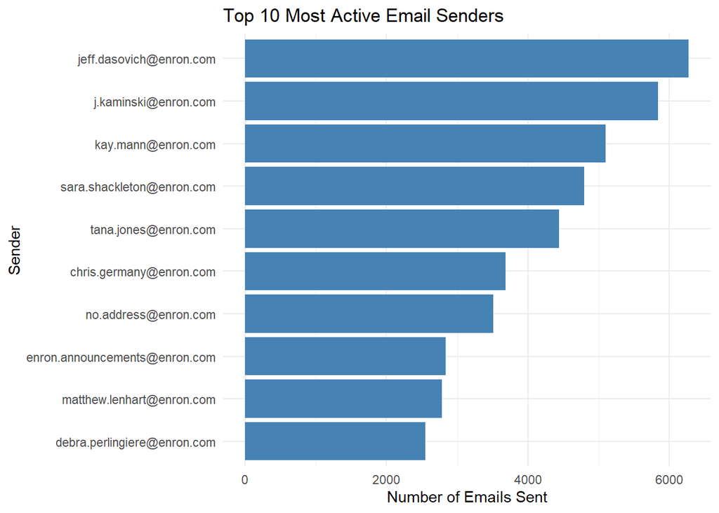

## Step 4: Email Activity by Role

```
## # A tibble: 10 × 2
##    status            n_sent
##    <fct>              <int>
##  1 Employee           36157
##  2 N/A                23331
##  3 Vice President     17158
##  4 Manager            13447
##  5 Trader              3800
##  6 President           3619
##  7 Director            2945
##  8 CEO                 1388
##  9 Managing Director   1176
## 10 In House Lawyer      763
```

```
## # A tibble: 9 × 2
##   status            n_sent
##   <fct>              <int>
## 1 Employee           36157
## 2 Vice President     17158
## 3 Manager            13447
## 4 Trader              3800
## 5 President           3619
## 6 Director            2945
## 7 CEO                 1388
## 8 Managing Director   1176
## 9 In House Lawyer      763
```

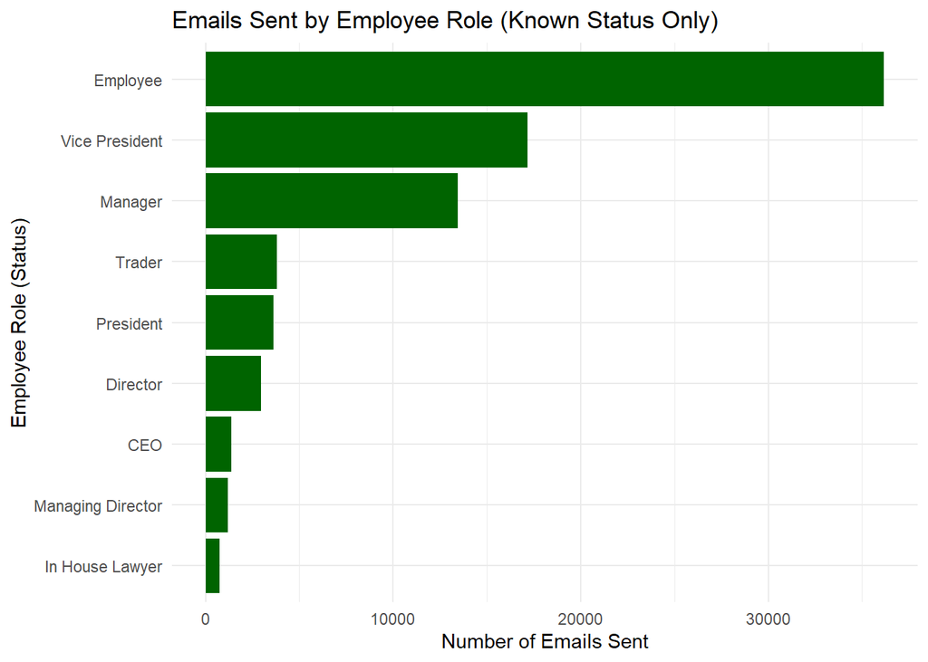

Observation: Employees and Vice Presidents were the most active communicators.

## Step 5: Monthly Email Volume

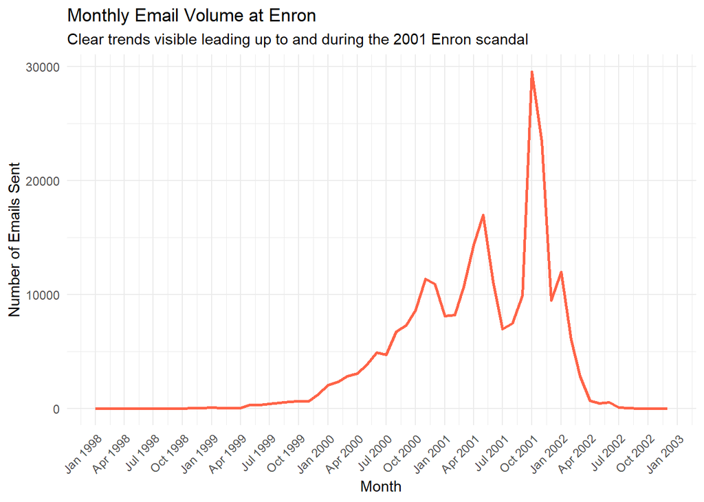

Insight: Email volume shows clear trends leading up to and during the 2001 Enron scandal.

## Step 6: Subject Line Word Frequency

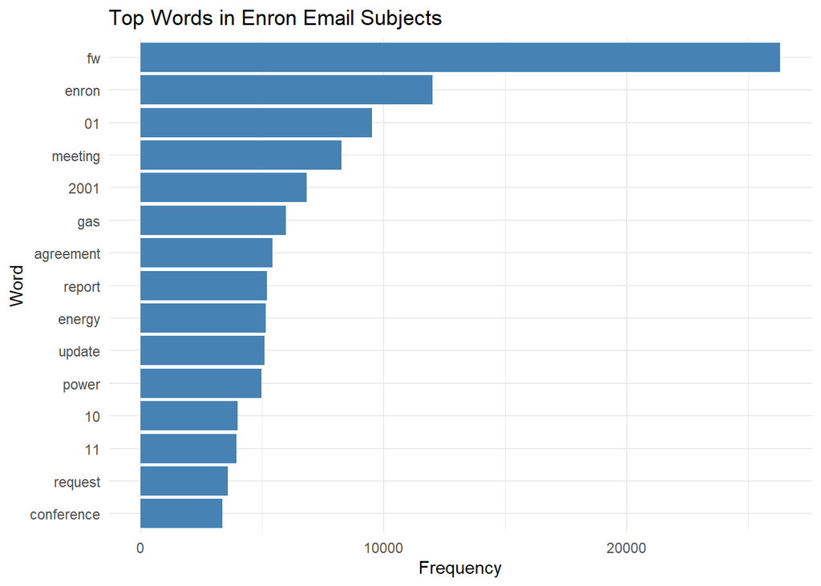

Observation: Frequent terms like “fw,” “meeting,” “gas,” and “update” reflecting operational discussions, internal coordination, and energy-related business communications within Enron.

## Step 7: Interactive Shiny App

To complement the static analysis, I developed a **Shiny web application** that enables users to interactively explore the Enron email dataset.

## Features of the App:

- Filter emails by **sender** or **employee role**
- View **email volume trends** over time
- Explore **frequent words** in email subject lines
- Visualize insights using interactive plots and tables

To run the app locally:

shiny::runApp(“app.R”)

## README:

Tools and libraries used:

dplyr, ggplot2, lubridate, tidytext, shiny